# PM566 Lab 4

Echo Tang

2022-09-14

## Step 1: Reading in data

```r
setwd("~/pm566/labs/lab4")
library(tidyverse)
library(data.table)
library(lubridate)
if (!file.exists("../lab3/met_all.gz"))
  download.file(
    url = "https://raw.githubusercontent.com/USCbiostats/data-science-data/master/02_met/met_all.gz",
    destfile = "met_all.gz",
    method   = "libcurl",
    timeout  = 60
    )
met <- data.table::fread("../lab3/met_all.gz")
```

## Step 2: Prepare the data

```r
met = met[met$temp > -17, ]
summary(met)
```

```
##      USAFID            WBAN            year          month        day
##  Min.   :690150   Min.   :  116   Min.   :2019   Min.   :8   Min.   : 1
##  1st Qu.:720927   1st Qu.: 3705   1st Qu.:2019   1st Qu.:8   1st Qu.: 8
##  Median :722720   Median :13841   Median :2019   Median :8   Median :16
##  Mean   :723095   Mean   :29496   Mean   :2019   Mean   :8   Mean   :16
##  3rd Qu.:725090   3rd Qu.:54768   3rd Qu.:2019   3rd Qu.:8   3rd Qu.:24
##  Max.   :726813   Max.   :94998   Max.   :2019   Max.   :8   Max.   :31
##
##       hour            min             lat             lon
##  Min.   : 0.00   Min.   : 0.00   Min.   :24.55   Min.   :-124.29
##  1st Qu.: 6.00   1st Qu.:20.00   1st Qu.:33.98   1st Qu.: -98.02
##  Median :11.00   Median :48.00   Median :38.37   Median : -91.74
##  Mean   :11.46   Mean   :39.23   Mean   :37.97   Mean   : -92.14
##  3rd Qu.:17.00   3rd Qu.:55.00   3rd Qu.:41.96   3rd Qu.: -82.99
##  Max.   :23.00   Max.   :59.00   Max.   :48.94   Max.   : -68.31
##
##       elev           wind.dir      wind.dir.qc        wind.type.code
##  Min.   : -13.0   Min.   :  3      Length:2317204     Length:2317204
##  1st Qu.: 101.0   1st Qu.:120      Class :character   Class :character
##  Median : 252.0   Median :180      Mode  :character   Mode  :character
##  Mean   : 415.1   Mean   :185
##  3rd Qu.: 400.0   3rd Qu.:260
##  Max.   :9999.0   Max.   :360
##                   NA's   :732170
##     wind.sp       wind.sp.qc          ceiling.ht    ceiling.ht.qc
##  Min.   : 0.00   Length:2317204     Min.   :    0   Min.   :1.000
##  1st Qu.: 0.00   Class :character   1st Qu.: 3048   1st Qu.:5.000
##  Median : 2.10   Mode  :character   Median :22000   Median :5.000
##  Mean   : 2.46                      Mean   :16171   Mean   :4.945
##  3rd Qu.: 3.60                      3rd Qu.:22000   3rd Qu.:5.000
##  Max.   :36.00                      Max.   :22000   Max.   :9.000
##  NA's   :31743                      NA's   :73437
##  ceiling.ht.method    sky.cond            vis.dist      vis.dist.qc
##  Length:2317204     Length:2317204     Min.   :     0   Length:2317204
##  Class :character   Class :character   1st Qu.: 16093   Class :character
##  Mode  :character   Mode  :character   Median : 16093   Mode  :character
##                                        Mean   : 14924
##                                        3rd Qu.: 16093
##                                        Max.   :160000
##                                        NA's   :33666
```

[output cut: 9 more lines]

```
##  Min.   :-37.20   Length:2317204     Min.   : 960.5    Min.   :1.000
##  1st Qu.: 13.80   Class :character   1st Qu.:1011.8    1st Qu.:5.000
##  Median : 18.10   Mode  :character   Median :1014.1    Median :9.000
##  Mean   : 17.02                      Mean   :1014.2    Mean   :7.696
##  3rd Qu.: 21.70                      3rd Qu.:1016.4    3rd Qu.:9.000
##  Max.   : 36.00                      Max.   :1059.9    Max.   :9.000
##  NA's   :6287                        NA's   :1606783
##        rh
##  Min.   :  0.833
##  1st Qu.: 55.790
##  Median : 76.554
##  Mean   : 71.641
##  3rd Qu.: 90.629
##  Max.   :100.000
##  NA's   :6287
```

From the summary of the dataset, there are NA values in the dewpoint and windspeed variables, which we want to answer our question. There are also 9999 values in the elevation column which we also want to clean out.

```r
dewpoint_na = is.na(met$dew.point)
windspeed_na = is.na(met$wind.sp)
elev_na = met$elev == 9999
met = met[!dewpoint_na & !windspeed_na & !elev_na, ]

# Double check to make sure all the NA values are cleaned out
summary(met)
```

```
##      USAFID            WBAN            year          month        day
##  Min.   :690150   Min.   :  116   Min.   :2019   Min.   :8   Min.   : 1.00
##  1st Qu.:720928   1st Qu.: 3713   1st Qu.:2019   1st Qu.:8   1st Qu.: 8.00
##  Median :722745   Median :13865   Median :2019   Median :8   Median :16.00
##  Mean   :723109   Mean   :29639   Mean   :2019   Mean   :8   Mean   :16.02
##  3rd Qu.:725104   3rd Qu.:54769   3rd Qu.:2019   3rd Qu.:8   3rd Qu.:24.00
##  Max.   :726813   Max.   :94998   Max.   :2019   Max.   :8   Max.   :31.00
##
##       hour            min             lat             lon
##  Min.   : 0.00   Min.   : 0.00   Min.   :24.55   Min.   :-124.29
##  1st Qu.: 6.00   1st Qu.:21.00   1st Qu.:34.02   1st Qu.: -98.02
##  Median :11.00   Median :48.00   Median :38.37   Median : -91.72
##  Mean   :11.45   Mean   :39.26   Mean   :37.97   Mean   : -92.13
##  3rd Qu.:17.00   3rd Qu.:55.00   3rd Qu.:41.96   3rd Qu.: -82.98
##  Max.   :23.00   Max.   :59.00   Max.   :48.94   Max.   : -68.31
##
##       elev           wind.dir      wind.dir.qc        wind.type.code
##  Min.   : -13.0   Min.   :  3      Length:2279783     Length:2279783
##  1st Qu.: 101.0   1st Qu.:120      Class :character   Class :character
##  Median : 252.0   Median :180      Mode  :character   Mode  :character
##  Mean   : 411.1   Mean   :185
##  3rd Qu.: 400.0   3rd Qu.:260
##  Max.   :4113.0   Max.   :360
##                   NA's   :698695
##     wind.sp        wind.sp.qc          ceiling.ht    ceiling.ht.qc
##  Min.   : 0.000   Length:2279783     Min.   :    0   Min.   :1.000
##  1st Qu.: 0.000   Class :character   1st Qu.: 3048   1st Qu.:5.000
##  Median : 2.100   Mode  :character   Median :22000   Median :5.000
##  Mean   : 2.463                      Mean   :16158   Mean   :4.941
##  3rd Qu.: 3.600                      3rd Qu.:22000   3rd Qu.:5.000
##  Max.   :36.000                      Max.   :22000   Max.   :9.000
##                                      NA's   :69824
##  ceiling.ht.method    sky.cond            vis.dist      vis.dist.qc
##  Length:2279783     Length:2279783     Min.   :     0   Length:2279783
##  Class :character   Class :character   1st Qu.: 16093   Class :character
##  Mode  :character   Mode  :character   Median : 16093   Mode  :character
##                                        Mean   : 14928
##                                        3rd Qu.: 16093
##                                        Max.   :160000
##                                        NA's   :29939
```

[output cut: 9 more lines]

```
##  Min.   :-37.20   Length:2279783     Min.   : 960.5    Min.   :1.000
##  1st Qu.: 13.80   Class :character   1st Qu.:1011.8    1st Qu.:5.000
##  Median : 18.10   Mode  :character   Median :1014.1    Median :9.000
##  Mean   : 17.03                      Mean   :1014.2    Mean   :7.688
##  3rd Qu.: 21.70                      3rd Qu.:1016.4    3rd Qu.:9.000
##  Max.   : 36.00                      Max.   :1059.9    Max.   :9.000
##                                      NA's   :1576940
##        rh
##  Min.   :  0.8334
##  1st Qu.: 55.8763
##  Median : 76.5561
##  Mean   : 71.6826
##  3rd Qu.: 90.6667
##  Max.   :100.0000
##
```

```r
met$date = as.Date(paste(met$year, met$month, met$day, sep = "-"), format = "%Y-%m-%d")
met_filtered = met[lubridate::day(ymd(met$date)) >= 1 & lubridate::day(ymd(met$date)) <= 7, ]

met_avg = met_filtered[, .(temp = mean(temp, na.rm = TRUE),
                 rh = mean(rh, na.rm = TRUE),
                 wind.sp = mean(wind.sp, na.rm = TRUE),
                 vis.dist = mean(vis.dist, na.rm = TRUE),
                 dew.point = mean(dew.point, na.rm = TRUE),
                 lat = mean(lat, na.rm = TRUE),
                 lon = mean(lon, na.rm = TRUE),
                 elev = mean(elev, na.rm = TRUE)
), by = "USAFID"]

met_avg$region = ifelse(met_avg$lon > -98 & met_avg$lat > 39.71, "NE",
                ifelse(met_avg$lon <= -98 & met_avg$lat > 39.71, "NW",
                ifelse(met_avg$lon > -98 & met_avg$lat <= 39.71, "SE",
                "SW")))
met_avg[, elev_cat := fifelse(elev > 252, "high", "low")]
```

## Step 3: examine the wind speed and dew point temperature by region

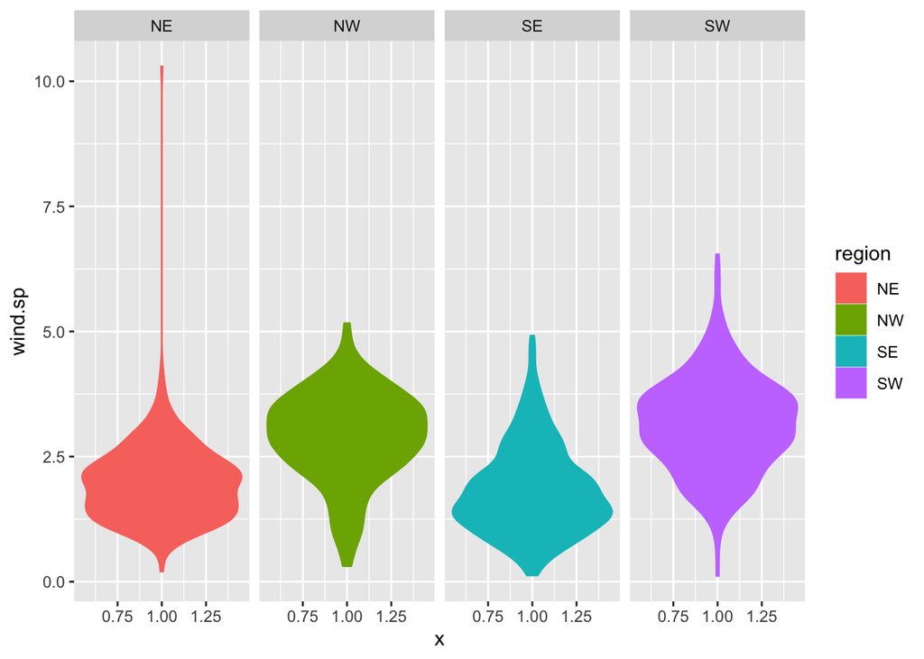

```r
met_avg %>% ggplot() + geom_violin(mapping = aes(x = 1, y = wind.sp, color = region, fill = region), na.rm = TRUE) + facet_wrap(~ region, nrow = 1)
```

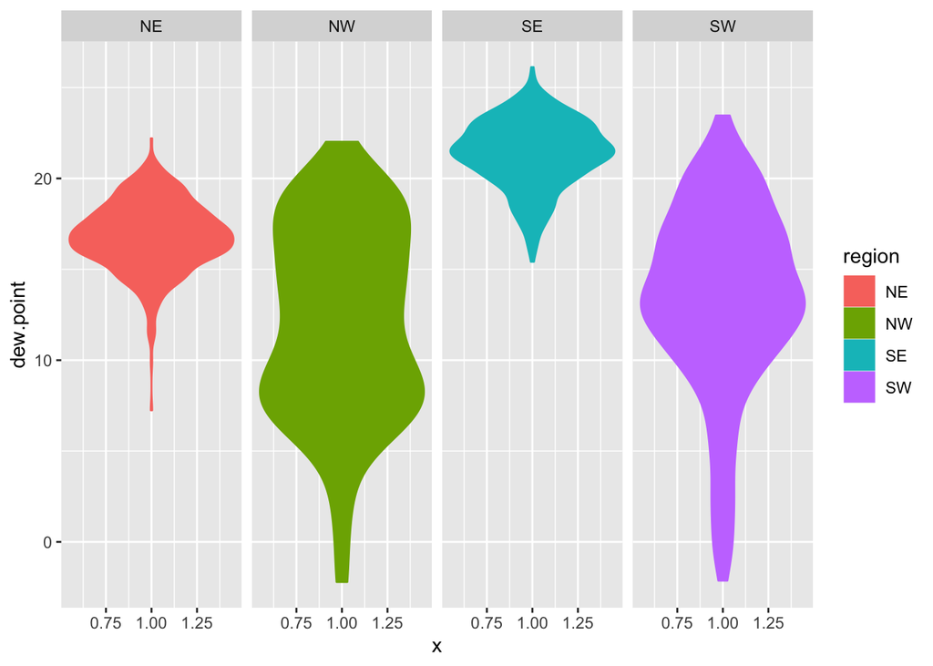

```r
met_avg %>% ggplot() + geom_violin(mapping = aes(x = 1, y = dew.point, color = region, fill = region), na.rm = TRUE) + facet_wrap(~ region, nrow = 1)
```

The wind speeds have similar distributions with similar minimums and maximums with the exception of NE, which has a larger range than the other regions. Furthermore, in the SE region, more values seem to be below the measure of center than the other regions. All regions’ most frequent wind speeds seem to reflect the center of the data such that the plots are shaped almost like a top. On the other hand, the dew point temperatures by region have much more variability. The southeast region has the highest dew point temperatures, where as both northwest and southwest regions have larger ranges of dew point temperatures. For the northwest region in particular, there are two “nodes” where dew point temperatures around 9 and 17 degrees are very frequent.

## Step 4: geom_jitter and stat_smooth

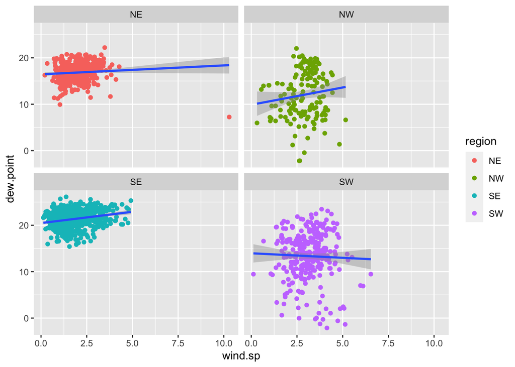

```r
met_avg %>% ggplot() + geom_jitter(mapping = aes(x = wind.sp, y = dew.point, color = region), na.rm = TRUE) +
  stat_smooth(mapping = aes(x = wind.sp, y = dew.point), method = "lm") +
  facet_wrap(~ region)
```

## Step 5: geom_bar

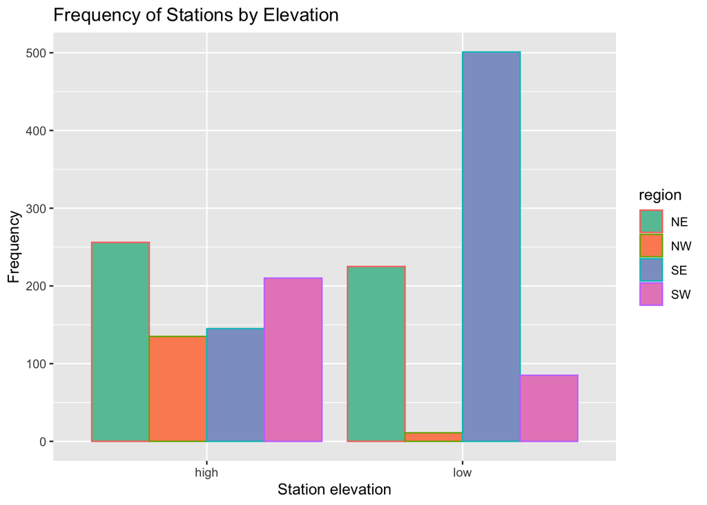

```r
met_avg %>% ggplot() + geom_bar(mapping = aes(x = elev_cat, color = region, fill = region), position = "dodge",  na.rm = TRUE) + scale_fill_brewer(palette ="Set2") + xlab("Station elevation") + ylab("Frequency") + ggtitle("Frequency of Stations by Elevation")
```

There are many more low elevation stations in the southeast region where as there are more high elevation stations in the northwest region than low elevation stations. Similarly to the northwest region, there are more high elevation than low elevation stations in the southwest region, as well as the northeast region (though the difference in frequency is not as significant as the three other regions).

## Step 6: Using stat_summary

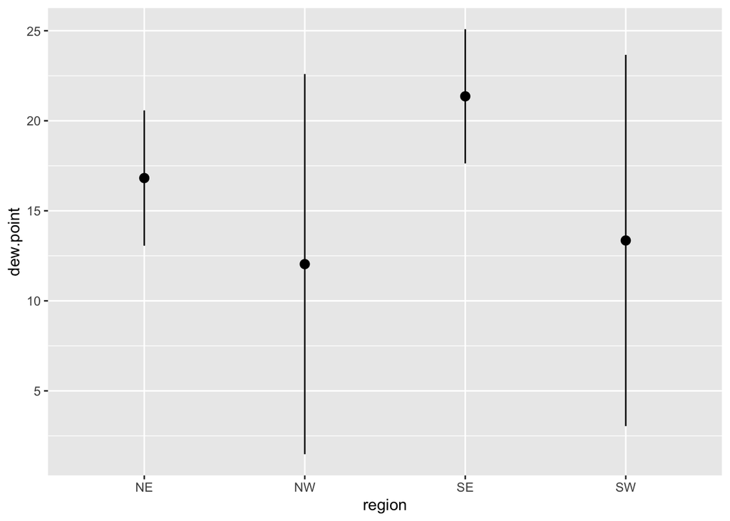

```r
met_avg %>% ggplot() + stat_summary(mapping = aes(x = region, y = dew.point), fun.data = mean_sdl, na.rm = TRUE)
```

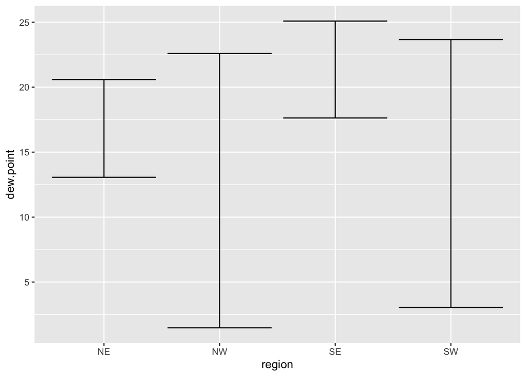

```r
met_avg %>% ggplot() + stat_summary(mapping = aes(x = region, y = dew.point), geom = "errorbar", fun.data = mean_sdl, na.rm = TRUE)
```

The dew point temperature ranges for the western regions are much larger than the eastern regions, which suggests that standard errors in these regions are larger than the eastern regions. The dew point temperature means for the eastern regions are higher than the eastern regions than the western regions, with the southeast mean dew point temperature being the highest of the four regions.

## Step 7: Map showing spatial trend

```r
library(leaflet)
rh.pal = colorNumeric(c('darkgreen', 'goldenrod', 'brown'), domain = met_avg$rh)
top10_rh = met_avg[rank(-rh) <= 10 ]

rh_map <- leaflet(met_avg) %>%
  addProviderTiles('CartoDB.Positron') %>%
  addCircles(
    lat = ~lat, lng = ~lon,
    label = ~paste0(rh), color = ~ rh.pal(rh),
    opacity = 1, fillOpacity = 1, radius = 500
    ) %>%
  addLegend('bottomleft', pal=rh.pal, values=met_avg$rh,
          title='Relative Humidity', opacity=1)

rh_map
```

[interactive chart not shown]

Generally, the further east in the United States, the more humid it is there. The coastlines usually have very high recorded humidities, where as less humid places are more inland. It seems like east and west directions determine humidity moreso than north and south.